# Homework 4

May Dixon

I’m vaguely resentful that you refered to the following as a “simple function”:

```r
Z.prop.test <- function(p1, n1, p0, p2=NULL, n2=NULL, alternative="two.sided", conf.level=0.95){

n1xp1.assumption.test <- n1*p1
n1x1minusp1.assumption.test<- n1*(1-p1)

if (n1xp1.assumption.test<=5 |n1x1minusp1.assumption.test<=5) {
      warning("WARNING: not valid to assume normal distribution. (n1*p1<5 or n1*(1-p1)<5) ")

}


if (is.null(p2) | is.null(n2)) {

 z <- (p1 - p0)/sqrt(p0 * (1 - p0)/n1)
            z

      if (alternative == "less"){

            p <- pnorm(z, lower.tail = TRUE)
            p

      }
      if (alternative == "greater"){

            p <- pnorm(z, lower.tail = FALSE)
            p
      }
      if (alternative == "two.sided"){

            p <- 2*pnorm(z)
            p
      }
}
# else{
if (!is.null(p2)  | !is.null(n2) ){

      n2xp2.assumption.test <- n2*p2
      n2x1minusp2.assumption.test<- n2*(1-p2)


      if (n2xp2.assumption.test<=5 |n2x1minusp2.assumption.test<=5) {
            warning("WARNING: not valid to assume normal distribution. (n2*p2<5 or n2*(1-p2)<5) ")
      }

      pstar <- (((p1*n1)+(p2*n2))/(n1+n2))
      z <- (p2 - p1)/sqrt((pstar * (1 - pstar)) * (1/n1 + 1/n2))
      z
      if (alternative=="two.sided"){
      #  2.sided is default
            p <- 1 - pnorm(z, lower.tail = TRUE) + pnorm(z, lower.tail = FALSE)
            p

      }

      if (alternative=="greater"){
       #conditionally evaluated
            p <- pnorm(z, lower.tail = FALSE)
            p

      }
      if (alternative == "less"){

            p <- pnorm(z, lower.tail = TRUE)
            p
      }


}
#calculating confidence interval around estimate
lower <- p1 + qnorm(0) * sqrt(p1 * (1 - p1)/n1)
upper <- p1 + qnorm(0.95) * sqrt(p1 * (1 - p1)/n1)
ci <- c(lower, upper)
ci

output<-list( Z= z, p.value = p, confidence_interval = ci)

       return(output)
}

#test
Z.prop.test(p1=0.6, n1=30, p0=0.8, alternative="less")
```

```
## $Z
## [1] -2.738613
##
## $p.value
## [1] 0.00308495
##
## $confidence_interval
## [1]      -Inf 0.7471202
```

```r
#test2
Z.prop.test(p1=0.56,n1=25, p2=0.7, n2=30, p0=0)
```

```
## $Z
## [1] 1.074709
##
## $p.value
## [1] 0.2825049
##
## $confidence_interval
## [1]      -Inf 0.7232968
```

```r
#p1=0.56
#p2=0.7
#n1=25
#n2=30
```

## [2]

*The dataset from Kamilar and Cooper has in it a large number of variables related to life history and body size. For this exercise, the end aim is to fit a simple linear regression model to predict longevity (“MaxLongevity_m”) measured in months from species’ brain size (“Brain_Size_Species_Mean”) measured in grams. Do the following for both longevity~brain size and log(longevity)~log(brain size).*

```r
KC<- read.csv("https://raw.githubusercontent.com/difiore/ADA2016/master/KamilarAndCooperData.csv", stringsAsFactors=FALSE, sep=",")
View(KC)
```

Fit the regression model and, using {ggplot2}, produce a scatterplot with the fitted line superimposed upon the data. Append the the fitted model equation to your plot (HINT: use the function geom_text()).

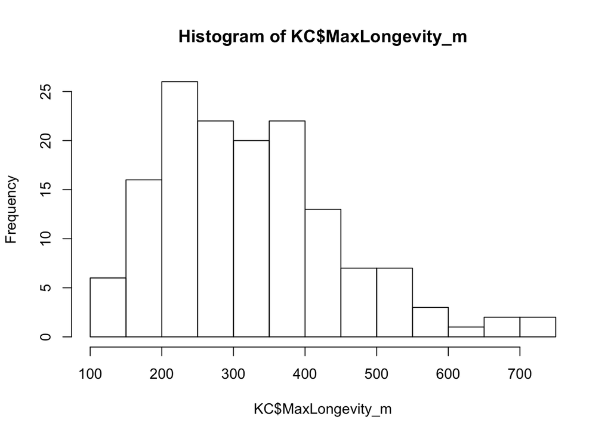

```r
library(ggplot2)
hist(KC$MaxLongevity_m)
```

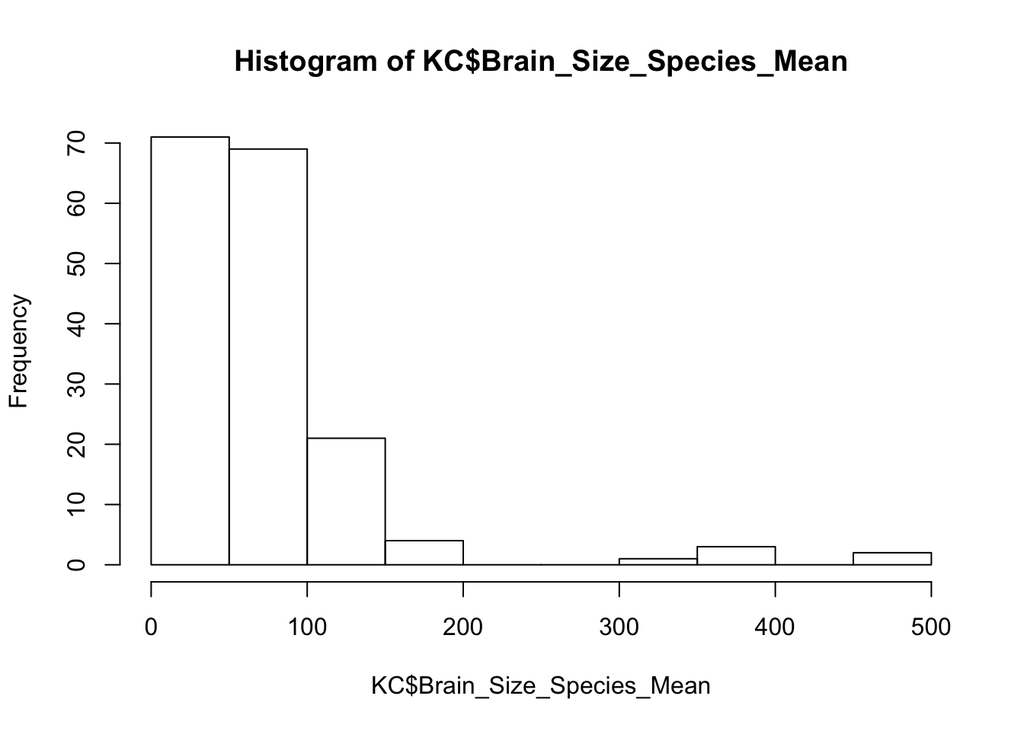

```r
hist(KC$Brain_Size_Species_Mean)
```

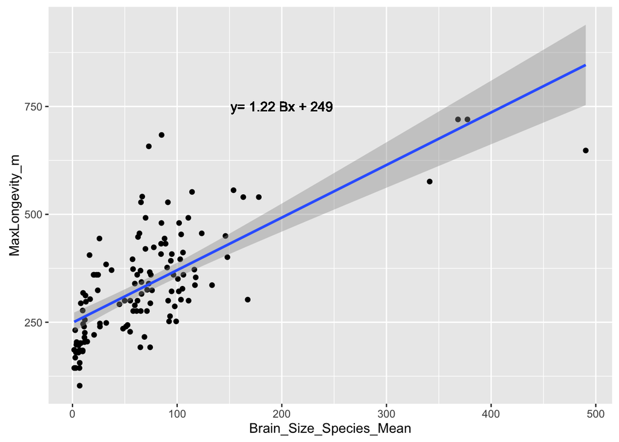

```r
BL<-lm(MaxLongevity_m ~ Brain_Size_Species_Mean, data=KC)


#so formula is roughly y= 1.22 Bx + 249
p <- ggplot(data = KC, aes(x = Brain_Size_Species_Mean, y = MaxLongevity_m))
p <- p + geom_point()
p <- p + geom_text(aes(x=200,y=750,label=paste("y= 1.22 Bx + 249")))
p <- p + geom_smooth(method = "lm", formula = y ~ x)
p
```

Identify and interpret the point estimate of the slope (β1), as well as the outcome of the test associated with the hypotheses H0: β1 = 0; HA: β1 ≠ 0. Also, find a 90 percent CI for the slope (β1) parameter.

```r
SBL<-summary(BL)
SBL
```

```
##
## Call:
## lm(formula = MaxLongevity_m ~ Brain_Size_Species_Mean, data = KC)
##
## Residuals:
##     Min      1Q  Median      3Q     Max
## -198.27  -61.92  -17.78   56.16  331.36
##
## Coefficients:
##                         Estimate Std. Error t value Pr(>|t|)
## (Intercept)             248.9523    11.1111   22.41   <2e-16 ***
## Brain_Size_Species_Mean   1.2180     0.1101   11.06   <2e-16 ***
## ---
## Signif. codes:  0 '***' 0.001 '**' 0.01 '*' 0.05 '.' 0.1 ' ' 1
##
## Residual standard error: 90.91 on 126 degrees of freedom
##   (85 observations deleted due to missingness)
## Multiple R-squared:  0.4928, Adjusted R-squared:  0.4887
## F-statistic: 122.4 on 1 and 126 DF,  p-value: < 2.2e-16
```

So, the estimate of slope (B1) is 1.2180. This means that on average, longevity increases by 1.218 months with every 1 gram increase in brain size. and this significantly different from 0, with a p value of <2e-16.

```r
ci<- confint(BL, level=0.90)
ci
```

```
##                                5 %      95 %
## (Intercept)             230.540738 267.36379
## Brain_Size_Species_Mean   1.035571   1.40041
```

There is a 90% probability that the true slope of B1 falls between 1.04 and 1.40

*Using your model, add lines for the 90 percent confidence and prediction interval bands on the plot and add a legend to differentiate between the lines.*

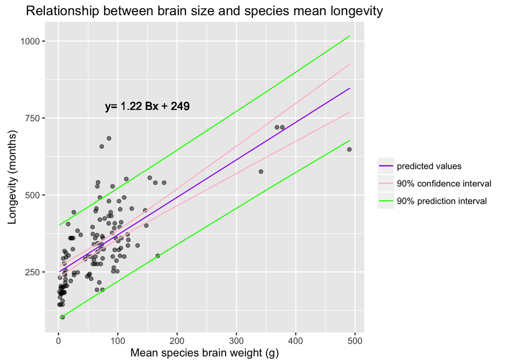

*Produce a point estimate and associated 90 percent PI for the longevity of a species whose brain weight is 800 gm. Do you trust the model to predict observations accurately for this value of the explanatory variable? Why or why not?*

```r
L800<- (1.218*800)+ 248.952 #deriving from formula
L800 #value
```

```
## [1] 1223.352
```

```r
L800/12 #in years
```

```
## [1] 101.946
```

### logged data

*Fit the regression model and, using {ggplot2}, produce a scatterplot with the fitted line superimposed upon the data. Append the the fitted model equation to your plot (HINT: use the function geom_text()).*

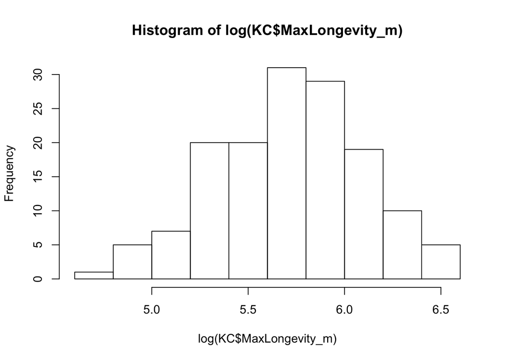

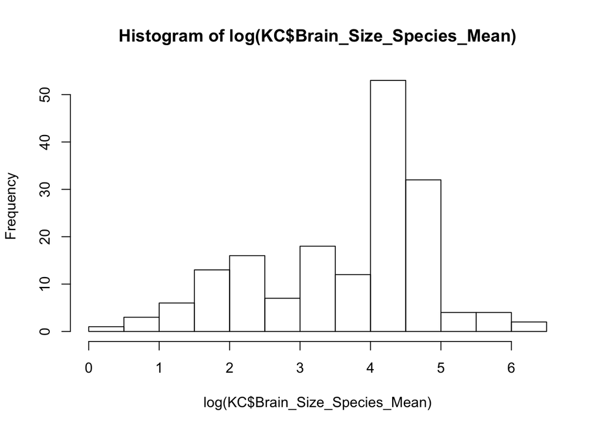

```
##
## Call:
## lm(formula = log(MaxLongevity_m) ~ log(Brain_Size_Species_Mean),
##     data = KC)
##
## Coefficients:
##                  (Intercept)  log(Brain_Size_Species_Mean)
##                       4.8790                        0.2341
```

So, the formula is roughly: y= 0.234Bx + 4.8790

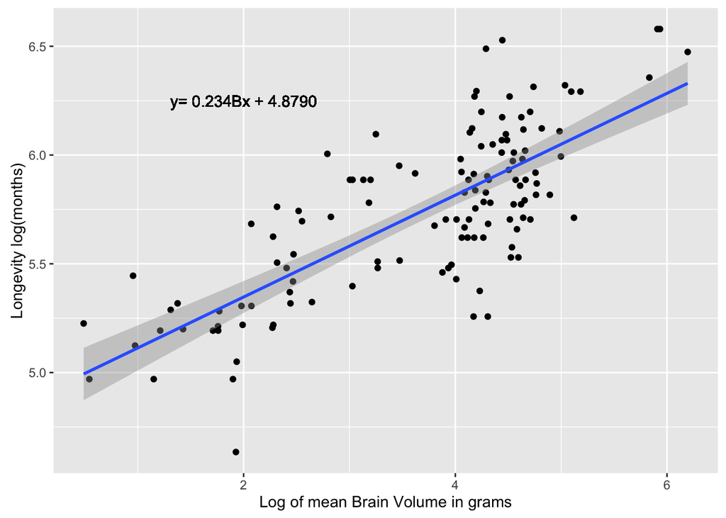

*Identify and interpret the point estimate of the slope (β1), as well as the outcome of the test associated with the hypotheses H0: β1 = 0; HA: β1 ≠ 0. Also, find a 90 percent CI for the slope (β1) parameter.*

```r
SBL<-summary(BL)
SBL
```

```
##
## Call:
## lm(formula = log(MaxLongevity_m) ~ log(Brain_Size_Species_Mean),
##     data = KC)
##
## Residuals:
##     Min      1Q  Median      3Q     Max
## -0.6955 -0.1750 -0.0097  0.1788  0.6084
##
## Coefficients:
##                              Estimate Std. Error t value Pr(>|t|)
## (Intercept)                   4.87895    0.06907   70.63   <2e-16 ***
## log(Brain_Size_Species_Mean)  0.23415    0.01781   13.15   <2e-16 ***
## ---
## Signif. codes:  0 '***' 0.001 '**' 0.01 '*' 0.05 '.' 0.1 ' ' 1
##
## Residual standard error: 0.2485 on 126 degrees of freedom
##   (85 observations deleted due to missingness)
## Multiple R-squared:  0.5784, Adjusted R-squared:  0.5751
## F-statistic: 172.9 on 1 and 126 DF,  p-value: < 2.2e-16
```

So, the estimate of slope (B1) is 0.234. This means that on average, longevity increases by 0.234 log(months) with every logged increase in brain size. and this significantly different from 0, with a p value of <2e-16.

```r
ci<- confint(BL, level=0.90)
ci
```

```
##                                    5 %      95 %
## (Intercept)                  4.7644934 4.9934084
## log(Brain_Size_Species_Mean) 0.2046396 0.2636595
```

There is a 90% probability that the true slope of B1 falls between 0.20 and 0.26

*Using your model, add lines for the 90 percent confidence and prediction interval bands on the plot and add a legend to differentiate between the lines.*

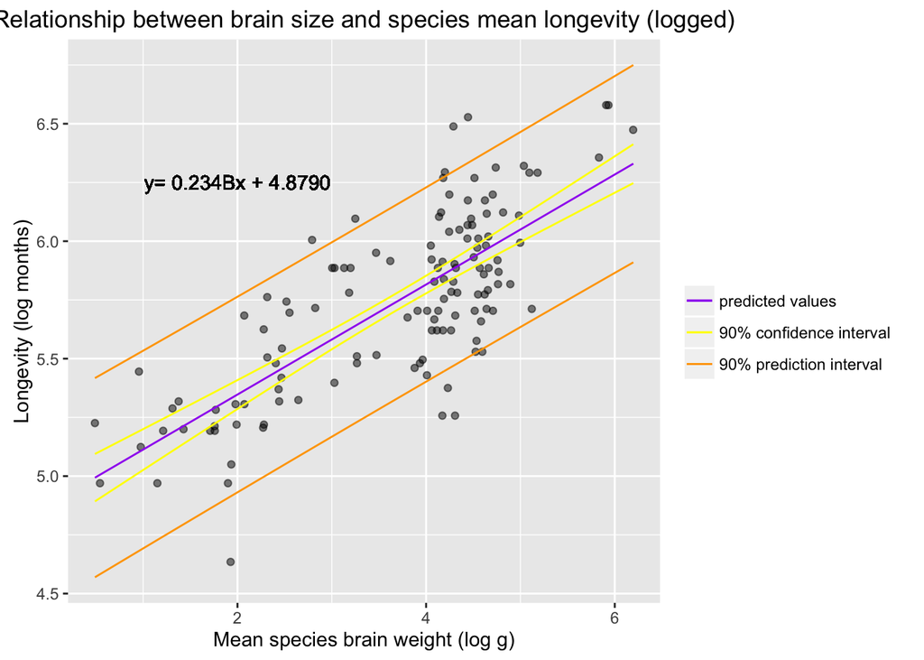

*Produce a point estimate and associated 90 percent PI for the longevity of a species whose brain weight is 800 gm. Do you trust the model to predict observations accurately for this value of the explanatory variable? Why or why not?*

```r
LL800<- (0.234*log(800))+4.879 #formula
exp(LL800) #converting to real world units
```

```
## [1] 628.414
```

```r
exp(LL800)/12 #converting to years
```

```
## [1] 52.36783
```

The model estimates that a species with a brain weight of 800g would live for 628 months, or about 52 years on average. This still isn’t totally trustworthy, because it is outside the range of values evaluated in this model, but may be slightly more trustworthy than the unlogged data, because it is not as far removed. Also, since human brain weight is around 1300g, this is more consistent with that.